# P03 - Study of the energy resolution and uncertainties of photon detectors using Bayesian methods.

Giulio Albertin | 2097420 Marco Dall’Ara | 2091251

# P03 - Study of the energy resolution and uncertainties of photons in NaI detector using Bayesian methods.

NaI detectors have wide fields of application for γ- and X-ray spectrometry. The energy resolution of these detectors is defined as the width of the detected energy spectra peaks (FWHM); it depends on

- the statistics of the charge creation process
- the properties of the detector, and primarily its charge collection efficiency
- the electronics noise

The resolution can be expressed as the squared sum of two terms

$$FWHM = \sqrt{w_d^2 + w_e^2}$$

where the first term depends on the detector properties as

$$w_d = 2 \sqrt{2 \ln{2} · F · Eγ · w
}$$

with F the Fano factor , Eγ the energy of the photon deposited energy and w is a constant that takes into account the electron-hole production energy threshold in NaI and the efficency of the PMT. The other term in eq. 1, we is connected with the readout electronics and depends on the detector capacitance, the size of the detector and the bias voltage. The following plot shows an uncalibrated energy spectrum collected with a NaI detector irradiated by a combination of three sources: 22 Na, 60 Co and 137 Cs.

The source nuclides emit the following photons:

| Nuclide | Photon energy (keV) |
| --- | --- |
| 22 Na | 511, 1274.577 |
| 137 Cs | 661.66 |
| 60 Co | 1173.24, 1332.51 |

as the image shows below.

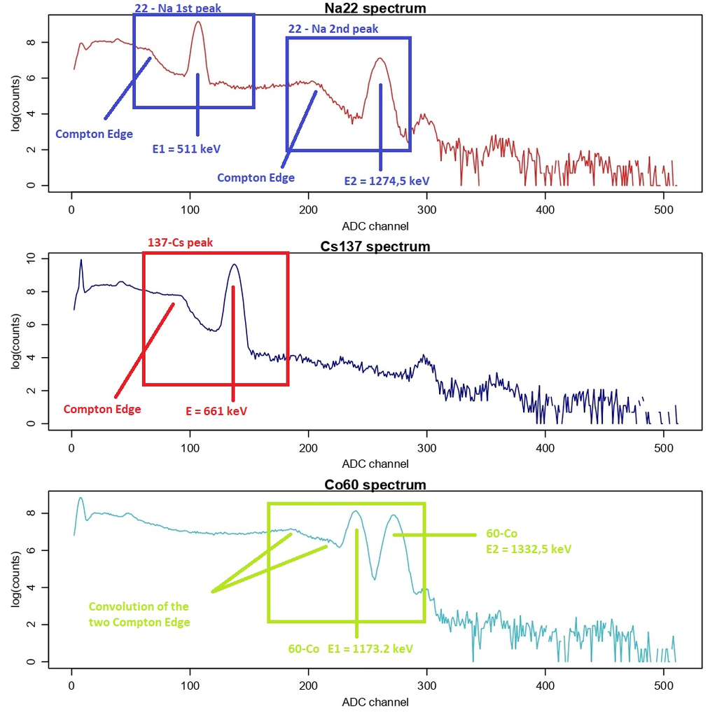

My Image

## 1. Infere the FWHM and the Centroids of each peak

Using statistical methods similar to that presented during the course, infere the FWHM of each γ peak for all available γ sources

First of all, we import the data and plot the spectra of the three sources.

```r
library(tidyverse)
library(rjags)
```

```r
Na_counts<-read.delim("22NaSpectrum_NaI_Tl_detector.dat", skip =2,header = TRUE)
Na_counts<-na.omit(Na_counts)
Na_dataset <- data.frame(Na_counts)

colnames(Na_dataset) <- c("ADC_channel", "Counts")
Na_dataset<-Na_dataset[(Na_dataset$Counts>=0),]

#plot(Na_dataset$ADC_channel,log(Na_dataset$Counts), type = 's', col='springgreen 2', main = '22-Na spectra, NaI detector', xlab = 'ADC channel [#]', ylab = "Log Counts [#]",cex.main = 1.5)
```

```r
Cs_counts<-read.delim("137CsSpectrum_NaI_Tl_detector.dat", skip =2,header = TRUE)
Cs_counts<-na.omit(Cs_counts)
Cs_dataset <- data.frame(Cs_counts)

colnames(Cs_dataset) <- c("ADC_channel", "Counts")
Cs_dataset<-Cs_dataset[(Cs_dataset$Counts>=0),]

#plot(Cs_dataset$ADC_channel,log(Cs_dataset$Counts), type = 's', col='coral 2', main = '137-Cs spectra, NaI detector', xlab = 'ADC channel [#]', ylab = "Log Counts [#]",cex.main = 1.5)
```

```r
Co_counts<-read.delim("60CoSpectrum_NaI_Tl_detector.dat", skip =2,header = TRUE)
Co_counts<-na.omit(Co_counts)
Co_dataset <- data.frame(Co_counts)

colnames(Co_dataset) <- c("ADC_channel", "Counts")
Co_dataset<-Co_dataset[(Co_dataset$Counts>=0),]
#plot(peak1_Co$ADC_channel,log(peak1_Co$Counts), type = 's', col='navy', main = '60-Co spectra, NaI detector', xlab = 'ADC channel [#]', ylab = "Log Counts [#]",cex.main = 1.5)
```

The parameters of the peaks are inferred with a JAGS model.

Generative model:

Signal: Gaussian fit

$$\text{Signal}(x |\text{N},\mu,\sigma) =
\frac{N}{\sqrt{2 \pi}\sigma} e^{[ -\frac{(x-\mu)^2}{2\sigma^2}]}$$

- $x$: ADC Channel
- $N$: amplitude of the signal
- $\mu$: centroid
- $\sigma$: standard deviation

Background: Linear Exponential

$$\text{Bkg_exp}(x |\alpha,\text{offset})
= e^{\tan[\alpha]x + \text{offset}}$$

- $\alpha$: slope [rad.]
- $offset$: offset

Measurement model: Poissonian distribution

$$\text{Poiss}(n)
= \frac{\lambda^{n}e^{-\lambda}}{n!}$$

- $\lambda$ = value of the generative model (signal + background)
- n = measured value (counts on the ADC Channel)

As Priors distribution for the Bayesian Inferesence we use exclusively Uniform distribution. We change the domain range for every peaks.

### 60-Co En = 1173.24 keV & 60-Co En = 1332.51 keV

Since the two peaks are near they overlap and then we chose the Signal function of the generative model to be the following:

$$\text{Signal}(x_{1}, x_{2}
|\text{N}_{1},\mu_{1},\sigma_{1}, \text{N}_{2},\mu_{2},\sigma_{2}) =
\frac{N_{1}}{\sqrt{2 \pi}\sigma_{1}} e^{
-\frac{(x_{1}-\mu_{1})^2}{2\sigma_{1}^2}} + \frac{N_{2}}{\sqrt{2
\pi}\sigma_{2}} e^{ -\frac{(x_{2}-\mu_{2})^2}{2\sigma_{2}^2}}$$

As Background we use the linear exponential function with the following form:

$$\text{Bkg_exp}(x |\alpha,\text{offset},
\mu_{1}, \mu_{2}) = e^{\tan(\alpha)(x - 0.5 \cdot (\mu_{1} + \mu_{2})) +
\text{offset}}$$

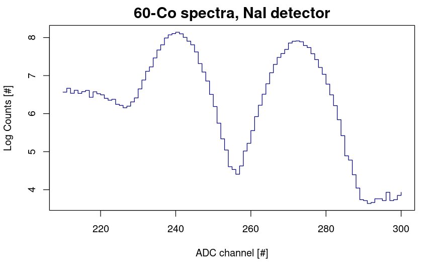

```r
peak1_Co = Co_dataset[(Co_dataset$ADC_channel>=210) & (Co_dataset$ADC_channel<=300),]
plot(peak1_Co$ADC_channel,log(peak1_Co$Counts), type = 's', col='navy', main = '60-Co spectra, NaI detector', xlab = 'ADC channel [#]', ylab = "Log Counts [#]",cex.main = 1.5)
```

```r
#define the model for both the Co peaks
exp.background.model.2 <- "model{
    #data likelihood

    for (i in 1:length(x)){

         y[i] ~ dpois(points[i])

        points[i] <- N_1/sqrt(2*3.14*sigma_1*sigma_1)*exp((-(x[i]-mu_1)*(x[i]-mu_1))/(2*sigma_1*sigma_1)) +N_2/sqrt(2*3.14*sigma_2*sigma_2)*exp((-(x[i]-mu_2)*(x[i]-mu_2))/(2*sigma_2*sigma_2)) +exp(tan(slope.alpha)*(x[i]-(mu_1+mu_2)/2) + offset)
  # line generative model

    }

    #priors for the generative model

    N_1 ~ dunif(20000,40000)
    N_2~ dunif(20000,40000)
    mu_1 ~ dunif(230,250)
    mu_2 ~ dunif(265,280)

    sigma_1 ~ dunif(2,7)
    sigma_2 ~ dunif(2,7)

    offset ~ dunif(0,5)
    slope.alpha ~ dunif(-3.14/2, 0)


}"

peak2.jm <- jags.model(textConnection(exp.background.model.2),
    data = list(x = peak1_Co$ADC_channel, y = peak1_Co$Counts), n.chain = 3, quiet = TRUE)

update(peak2.jm , 1000, progress.bar = "none")

peak2.cs <- coda.samples(model = peak2.jm, variable.names = c("N_1", "N_2", "mu_1","mu_2", "sigma_1", "sigma_2", "offset", "slope.alpha"), n.iter = 10000, thin = 15, progress.bar = "none")

summary(peak2.cs)
```

```
Iterations = 2015:11990
Thinning interval = 15
Number of chains = 3
Sample size per chain = 666

1. Empirical mean and standard deviation for each variable,
   plus standard error of the mean:

                  Mean        SD  Naive SE Time-series SE
N_1          3.697e+04 2.326e+02 5.203e+00      5.060e+00
N_2          3.381e+04 2.043e+02 4.571e+00      4.570e+00
mu_1         2.398e+02 3.021e-02 6.759e-04      6.592e-04
mu_2         2.721e+02 3.037e-02 6.795e-04      6.785e-04
offset       4.939e+00 2.093e-02 4.683e-04      5.701e-04
sigma_1      4.672e+00 2.504e-02 5.602e-04      5.731e-04
sigma_2      5.120e+00 2.587e-02 5.789e-04      6.464e-04
slope.alpha -3.926e-02 5.524e-04 1.236e-05      1.496e-05

2. Quantiles for each variable:

                  2.5%        25%        50%        75%      97.5%
N_1          3.650e+04  3.681e+04  3.698e+04  3.712e+04  3.743e+04
N_2          3.341e+04  3.367e+04  3.381e+04  3.394e+04  3.420e+04
mu_1         2.398e+02  2.398e+02  2.398e+02  2.399e+02  2.399e+02
mu_2         2.720e+02  2.721e+02  2.721e+02  2.721e+02  2.721e+02
offset       4.897e+00  4.924e+00  4.939e+00  4.953e+00  4.978e+00
sigma_1      4.624e+00  4.655e+00  4.672e+00  4.689e+00  4.724e+00
sigma_2      5.071e+00  5.103e+00  5.120e+00  5.136e+00  5.175e+00
slope.alpha -4.036e-02 -3.963e-02 -3.926e-02 -3.888e-02 -3.824e-02
```

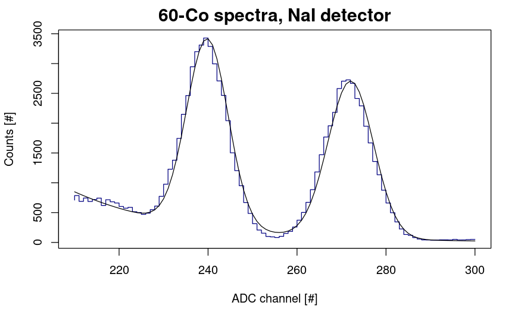

```r
#plot(peak2.cs)

peak2_mcmc <- as.mcmc(do.call(rbind, peak2.cs))

N_1 <- mean(peak2_mcmc[,1])
N_2 <-mean(peak2_mcmc[,2])
sigma_1 <- mean(peak2_mcmc[,6])
sigma_2 <- mean(peak2_mcmc[,7])
mu_1 <- mean(peak2_mcmc[,3])
mu_2 <- mean(peak2_mcmc[,4])
slope.alpha <- mean(peak2_mcmc[,8])
offset <- mean(peak2_mcmc[,5])
x <- peak1_Co$ADC_channel
y <- N_1/sqrt(2*3.14*sigma_1*sigma_1)*exp((-(x-mu_1)*(x-mu_1))/(2*sigma_1*sigma_1)) +N_2/sqrt(2*3.14*sigma_2*sigma_2)*exp((-(x-mu_2)*(x-mu_2))/(2*sigma_2*sigma_2)) +exp(tan(slope.alpha)*(x-(mu_1+mu_2)/2) + offset)

plot(peak1_Co$ADC_channel,(peak1_Co$Counts), type = 'S', col='navy', main = '60-Co spectra, NaI detector', xlab = 'ADC channel [#]', ylab = "Counts [#]",cex.main = 1.5)
lines(x,y)
```

### 22-Na En = 511 keV

For the following peaks we use as generative model the original Signal function and the linear exponential Background.

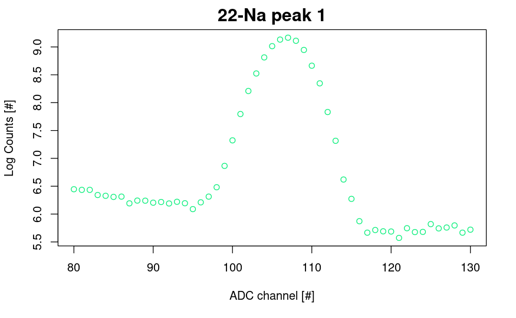

```r
# range of the first peak
Na_peak1 = Na_dataset[(Na_dataset$ADC_channel>=80) & (Na_dataset$ADC_channel<=130),]
plot(Na_peak1$ADC_channel,log(Na_peak1$Counts),  col='springgreen 2', main = '22-Na peak 1', xlab = 'ADC channel [#]', ylab = "Log Counts [#]",cex.main = 1.5)
```

```r
# rjags model as .bugs file
# peak describe a gaussian
# with an exponential background exp(m(x - mu) + offset)
exp.background.model.Na.1 <- "model{
    #data likelihood of the poisson
    for (i in 1:length(x)){

         y[i] ~ dpois(points[i])

        points[i] <- N/sqrt(2*3.14*sigma*sigma)*exp((-(x[i]-mu)*(x[i]-mu))/(2*sigma*sigma)) +exp(tan(slope)*(x[i]-mu) + offset)

    }

    # priors for the generative model
    # amplitude
    N ~ dunif(10000,90000)
    # range of the centroid
    mu ~ dunif(100,114)
    # range of std
    sigma ~ dunif(0.01,10)
    offset ~ dunif(0,500)
    # slope will be tan(slope)
    slope ~ dunif(-3.14/2, 0)


}"

# initialization of the model
Na_peak1.jm <- jags.model(textConnection(exp.background.model.Na.1),
    data = list(x = Na_peak1$ADC_channel, y = Na_peak1$Counts), n.chain = 3, quiet = TRUE)

# burn-in
update(Na_peak1.jm , 1000, progress.bar = "none")

# creates the coda sample
Na_peak1.cs <- coda.samples(model = Na_peak1.jm, variable.names = c("N", "mu", "sigma", "offset", "slope"), n.iter = 10000, thin = 15, progress.bar = "none")

summary(Na_peak1.cs)
```

```
Iterations = 2015:11990
Thinning interval = 15
Number of chains = 3
Sample size per chain = 666

1. Empirical mean and standard deviation for each variable,
   plus standard error of the mean:

             Mean        SD  Naive SE Time-series SE
N       7.332e+04 2.909e+02 6.509e+00      6.512e+00
mu      1.067e+02 1.306e-02 2.923e-04      2.846e-04
offset  5.958e+00 9.628e-03 2.154e-04      2.154e-04
sigma   3.145e+00 1.033e-02 2.312e-04      2.283e-04
slope  -1.651e-02 5.080e-04 1.136e-05      1.146e-05

2. Quantiles for each variable:

             2.5%        25%        50%        75%      97.5%
N       7.274e+04  7.313e+04  7.332e+04  7.353e+04  7.388e+04
mu      1.066e+02  1.066e+02  1.067e+02  1.067e+02  1.067e+02
offset  5.939e+00  5.951e+00  5.958e+00  5.964e+00  5.976e+00
sigma   3.125e+00  3.138e+00  3.145e+00  3.151e+00  3.166e+00
slope  -1.748e-02 -1.686e-02 -1.651e-02 -1.617e-02 -1.551e-02
```

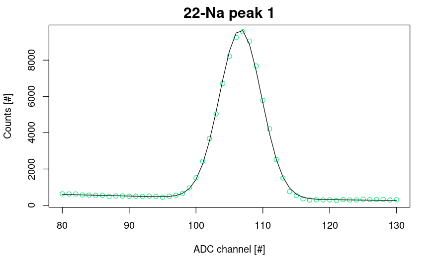

```r
#plot(Na_peak1.cs)

# merge the chains on a mcmc objects
Na_peak1_mcmc <- as.mcmc(do.call(rbind, Na_peak1.cs))
#head(Na_peak1_mcmc)

# mean values of the parameters form the mcmc object
Na_peak1_params <- c("N" = mean(Na_peak1_mcmc[,1]),"mu" = mean(Na_peak1_mcmc[,2]), "offset" = mean(Na_peak1_mcmc[,3]), "sigma" = mean(Na_peak1_mcmc[,4]), "alpha" = mean(Na_peak1_mcmc[,5]))
#Na_peak1_params


# fit of the gaussian peaks + the exponential background
pred_Na_peak1 <-  Na_peak1_params[1] /sqrt(2*3.14*Na_peak1_params[4]*Na_peak1_params[4])*exp((-(Na_peak1$ADC_channel-Na_peak1_params[2])*(Na_peak1$ADC_channel-Na_peak1_params[2]))/(2*Na_peak1_params[4]*Na_peak1_params[4])) +exp(tan(Na_peak1_params[5])*(Na_peak1$ADC_channel - Na_peak1_params[2]) + Na_peak1_params[3])

#plot of the data and the fit
plot(Na_peak1$ADC_channel, Na_peak1$Counts,  col='springgreen 2', main = '22-Na peak 1', xlab = 'ADC channel [#]', ylab = "Counts [#]",cex.main = 1.5)
lines(Na_peak1$ADC_channel, pred_Na_peak1)
```

### 22-Na En = 1274.577 keV

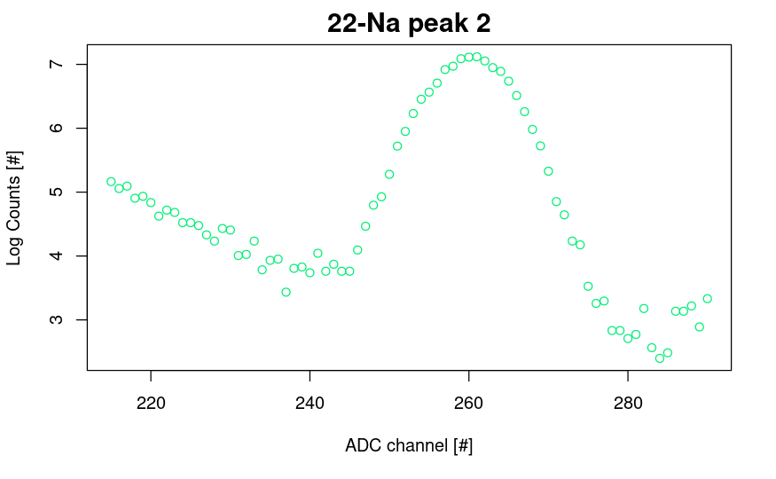

```r
# range of the second peak
Na_peak2 = Na_dataset[(Na_dataset$ADC_channel>=215) & (Na_dataset$ADC_channel<=290),]
plot(Na_peak2$ADC_channel,log(Na_peak2$Counts),  col='springgreen 2', main = '22-Na peak 2', xlab = 'ADC channel [#]', ylab = "Log Counts [#]",cex.main = 1.5)
```

```r
# rjags model as .bugs file
# peak describe a gaussian
# with an exponential background exp(m(x - mu) + offset)
exp.background.model.Na.2 <- "model{
    #data likelihood
    for (i in 1:length(x)){

         y[i] ~ dpois(points[i])

        points[i] <- N/sqrt(2*3.14*sigma*sigma)*exp((-(x[i]-mu)*(x[i]-mu))/(2*sigma*sigma)) +exp(tan(slope)*(x[i]-mu) + offset)  # line generative model

    }

    #priors for the generative model
    # specific range of the amplitude
    N ~ dunif(10000,70000)
    # specific range of the centroid
    mu ~ dunif(250,270)
    # specific range of the sigma
    sigma ~ dunif(0.01,10)
    offset ~ dunif(0,40)
    slope ~ dunif(-3.14/2, 0)


}"

# initialization of the model
Na_peak2.jm <- jags.model(textConnection(exp.background.model.Na.2),
    data = list(x = Na_peak2$ADC_channel, y = Na_peak2$Counts), n.chain = 3, quiet = TRUE)

# burn-in
update(Na_peak2.jm , 1000, progress.bar="none")

# creates the coda sample
Na_peak2.cs <- coda.samples(model = Na_peak2.jm, variable.names = c("N", "mu", "sigma", "offset", "slope"), n.iter = 10000, thin = 15, progress.bar="none")

summary(Na_peak2.cs)
```

```
Iterations = 2015:11990
Thinning interval = 15
Number of chains = 3
Sample size per chain = 666

1. Empirical mean and standard deviation for each variable,
   plus standard error of the mean:

             Mean        SD  Naive SE Time-series SE
N       1.537e+04 1.317e+02 2.947e+00      2.947e+00
mu      2.603e+02 4.391e-02 9.824e-04      1.005e-03
offset  3.367e+00 3.989e-02 8.925e-04      9.486e-04
sigma   5.114e+00 3.737e-02 8.359e-04      8.549e-04
slope  -3.321e-02 1.172e-03 2.622e-05      2.802e-05

2. Quantiles for each variable:

             2.5%        25%        50%        75%      97.5%
N       1.511e+04  1.527e+04  1.537e+04  1.545e+04  1.562e+04
mu      2.602e+02  2.602e+02  2.603e+02  2.603e+02  2.603e+02
offset  3.290e+00  3.339e+00  3.367e+00  3.394e+00  3.446e+00
sigma   5.038e+00  5.089e+00  5.114e+00  5.138e+00  5.189e+00
slope  -3.551e-02 -3.406e-02 -3.321e-02 -3.243e-02 -3.085e-02
```

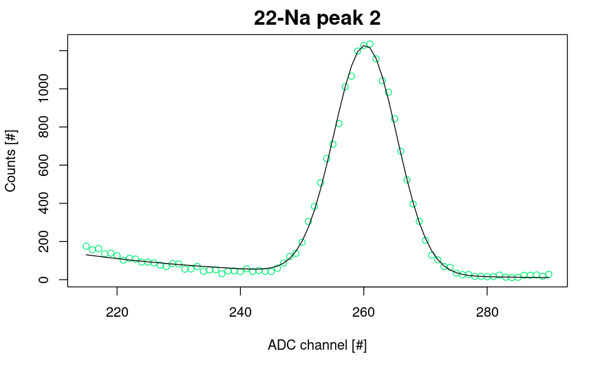

```r
#plot(Na_peak2.cs)

# merge the chains on a mcmc objects
Na_peak2_mcmc <- as.mcmc(do.call(rbind, Na_peak2.cs))
#head(Na_peak2_mcmc)

# mean values of the parameters form the mcmc object
Na_peak2_params <- c("N" = mean(Na_peak2_mcmc[,1]),"mu" = mean(Na_peak2_mcmc[,2]), "offset" = mean(Na_peak2_mcmc[,3]), "sigma" = mean(Na_peak2_mcmc[,4]), "alpha" = mean(Na_peak2_mcmc[,5]))
#Na_peak2_params

# fit of the gaussian peaks + the exponential background
pred_Na_peak2 <-  Na_peak2_params[1] /sqrt(2*3.14*Na_peak2_params[4]*Na_peak2_params[4])*exp((-(Na_peak2$ADC_channel-Na_peak2_params[2])*(Na_peak2$ADC_channel-Na_peak2_params[2]))/(2*Na_peak2_params[4]*Na_peak2_params[4])) +exp(tan(Na_peak2_params[5])*(Na_peak2$ADC_channel - Na_peak2_params[2]) + Na_peak2_params[3])

#plot of the data and the fit
plot(Na_peak2$ADC_channel, Na_peak2$Counts,  col='springgreen 2', main = '22-Na peak 2', xlab = 'ADC channel [#]', ylab = "Counts [#]",cex.main = 1.5)
lines(Na_peak2$ADC_channel, pred_Na_peak2)
```

### 137-Cs En = 661.66 keV

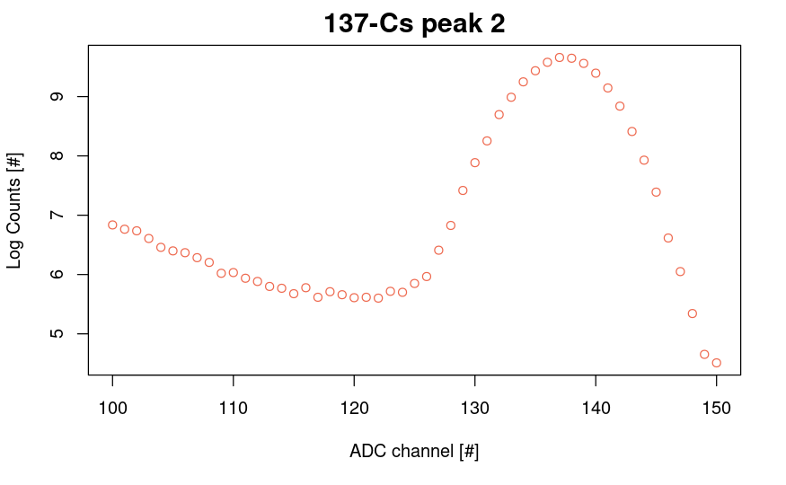

```r
# range of the Cesium peak
Cs_peak = Cs_dataset[(Cs_dataset$ADC_channel>=100) & (Cs_dataset$ADC_channel<=150),]
plot(Cs_peak$ADC_channel, log(Cs_peak$Counts),  col='coral 2', main = '137-Cs peak 2', xlab = 'ADC channel [#]', ylab = "Log Counts [#]",cex.main = 1.5)
```

```r
# rjags model as .bugs file
# peak describe a gaussian
# with an exponential background exp(m(x - mu) + offset)
exp.background.model.Cs <- "model{
    #data likelihood
    for (i in 1:length(x)){

         y[i] ~ dpois(points[i])

        points[i] <- N/sqrt(2*3.14*sigma*sigma)*exp((-(x[i]-mu)*(x[i]-mu))/(2*sigma*sigma)) +exp(tan(slope)*(x[i]-mu) + offset)  # line generative model

    }

    #priors for the generative model

    # specific range of the amplitude
    N ~ dunif(80000,150000)
    # specific range of the centroid
    mu ~ dunif(130,145)
    # specific range of the std
    sigma ~ dunif(0.01,10)
    offset ~ dunif(0,500)
    slope ~ dunif(-3.14/2, 0)


}"

# initialization of the model
Cs_peak.jm <- jags.model(textConnection(exp.background.model.Cs),
    data = list(x = Cs_peak$ADC_channel, y = Cs_peak$Counts), n.chain = 3, quiet=TRUE)

# burn-in
update(Cs_peak.jm , 1000, progress.bar = "none")

# creates the coda sample
Cs_peak.cs <- coda.samples(model = Cs_peak.jm, variable.names = c("N", "mu", "sigma", "offset", "slope"), n.iter = 10000, thin = 15, progress.bar = "none")

summary(Cs_peak.cs)
```

```
Iterations = 2015:11990
Thinning interval = 15
Number of chains = 3
Sample size per chain = 666

1. Empirical mean and standard deviation for each variable,
   plus standard error of the mean:

             Mean        SD  Naive SE Time-series SE
N       1.430e+05 3.863e+02 8.642e+00      8.959e+00
mu      1.372e+02 1.024e-02 2.291e-04      2.222e-04
offset  4.590e+00 3.551e-02 7.944e-04      1.256e-03
sigma   3.687e+00 8.135e-03 1.820e-04      1.926e-04
slope  -5.747e-02 1.224e-03 2.739e-05      4.328e-05

2. Quantiles for each variable:

             2.5%        25%        50%        75%      97.5%
N      142293.979  1.428e+05  1.430e+05  1.433e+05  1.438e+05
mu        137.157  1.372e+02  1.372e+02  1.372e+02  1.372e+02
offset      4.519  4.565e+00  4.590e+00  4.613e+00  4.658e+00
sigma       3.671  3.681e+00  3.687e+00  3.692e+00  3.704e+00
slope      -0.060 -5.827e-02 -5.743e-02 -5.666e-02 -5.513e-02
```

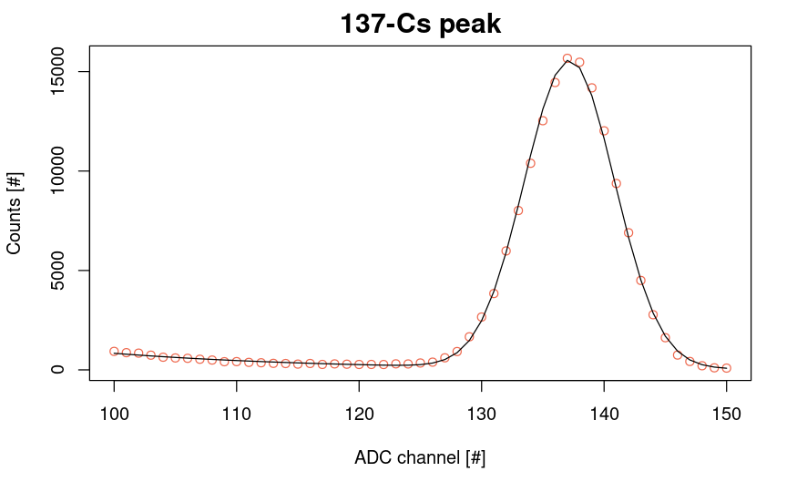

```r
#plot(Cs_peak.cs)

# merge the chains on a mcmc objects
Cs_peak_mcmc <- as.mcmc(do.call(rbind, Cs_peak.cs))
#head(Cs_peak_mcmc)

# mean values of the parameters form the mcmc object
Cs_peak_params <- c("N" = mean(Cs_peak_mcmc[,1]),"mu" = mean(Cs_peak_mcmc[,2]), "offset" = mean(Cs_peak_mcmc[,3]), "sigma" = mean(Cs_peak_mcmc[,4]), "alpha" = mean(Cs_peak_mcmc[,5]))
#Cs_peak_params

# fit of the gaussian peaks + the exponential background
pred_Cs_peak <-  Cs_peak_params[1] /sqrt(2*3.14*Cs_peak_params[4]*Cs_peak_params[4])*exp((-(Cs_peak$ADC_channel-Cs_peak_params[2])*(Cs_peak$ADC_channel-Cs_peak_params[2]))/(2*Cs_peak_params[4]*Cs_peak_params[4])) +exp(tan(Cs_peak_params[5])*(Cs_peak$ADC_channel - Cs_peak_params[2]) + Cs_peak_params[3])

#plot of the data and the fit
plot(Cs_peak$ADC_channel, Cs_peak$Counts,  col='coral 2', main = '137-Cs peak', xlab = 'ADC channel [#]', ylab = "Counts [#]",cex.main = 1.5)
lines(Cs_peak$ADC_channel, pred_Cs_peak)
```

## 2. Linear Calibration

Assuming a linear response of the detector as a function of energy, we perform a calibration of the detector associating the centroid of each peak to the nominal value of the detected γ full energy peak.

To infer the parameters we use again a JAGS model.

Generative model:

$$\ y = a + b \cdot x$$

- $a$ = offset
- $b$ = slope
- $x$ = centroid the peak

Measurement Model:

$$\text{Norm}(\sigma |E, y ) =
\frac{1}{\sqrt{2 \pi}\sigma} \exp \left[ -\frac{(E -
y(x))^2}{2\sigma^2}\right]$$

- $E$: true value of gamma peak, taken from literature
- $y(x)$: values of the peak from the generative model
- $sigma$: standard deviation

In this framework we adopt normal prior distributions.

```r
# linear model as .bug file for calibration
# the theoretical value, the fit,  and the measurement will have some discrepancy
# the difference of this two value will follow a normal distribution
# we also want to infer the value of sigma
linear.model <- "model{
    # Likelihood model for X
    for (i in 1:N){
      E[i] ~ dnorm(f[i], tau) # tau is precision (1 / variance)
          f[i] <- a + b* x[i]
    }
    # Prior model for p
    b ~ dnorm(0, 0.01)
    a ~ dnorm(0, 0.01)
    sigma ~ dnorm(1, 0.1)
    tau <- 1 / (sigma * sigma)

}"

# Photon energy of the peaks
E_gamma <- c(511, 1274.577, 661.66 , 1173.24, 1332.51)

# Channel energy of the peaks
E_ch <- c(1.066526e+02, 2.602560e+02, 1.371767e+02, 2.398e+02, 2.721e+02)

# initialization of the model
calibration.jags <- jags.model(textConnection(linear.model),
    data = list(x = E_ch, E = E_gamma, N = length(E_gamma)), n.chain = 3, quiet = TRUE)

#burn-in
update(calibration.jags , 1000, progress.bar = "none")

# creation of the coda sample
linear.pred <- coda.samples(model = calibration.jags, variable.names = c("a", "b", "sigma"), n.iter = 10000, thin = 15, progress.bar = "none")

# summary of the coda samples
summary(linear.pred)
```

```
Iterations = 2015:11990
Thinning interval = 15
Number of chains = 3
Sample size per chain = 666

1. Empirical mean and standard deviation for each variable,
   plus standard error of the mean:

         Mean      SD  Naive SE Time-series SE
a     -18.847 2.49968 0.0559225      0.0760856
b       4.968 0.01155 0.0002584      0.0003586
sigma   1.316 0.82502 0.0184573      0.0267513

2. Quantiles for each variable:

         2.5%      25%     50%     75%   97.5%
a     -22.468 -20.1486 -19.234 -18.122 -12.225
b       4.938   4.9646   4.970   4.974   4.986
sigma   0.461   0.7529   1.066   1.613   3.566
```

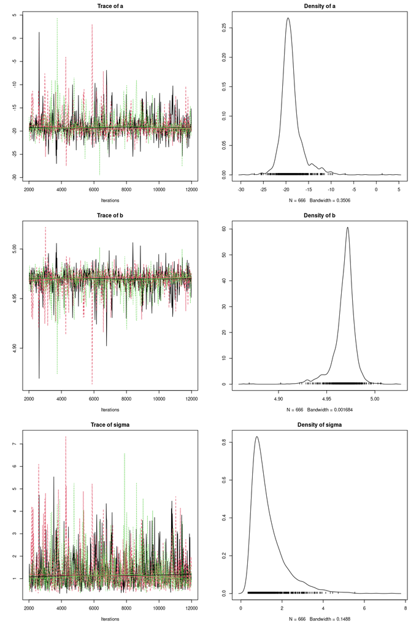

```r
# plot of the coda samples
plot(linear.pred)
```

```r
# store the chains as a mcmc object
calibration_mcmc <- as.mcmc(do.call(rbind, linear.pred))

#head(calibration_mcmc)

# calculate the ACF CORRELATIONS between the params
calibration.acf <- acf(calibration_mcmc, plot = FALSE) #plot = F will not show the plot of the ACF.

cal_names <- c("b", "a", expression(sigma))
```

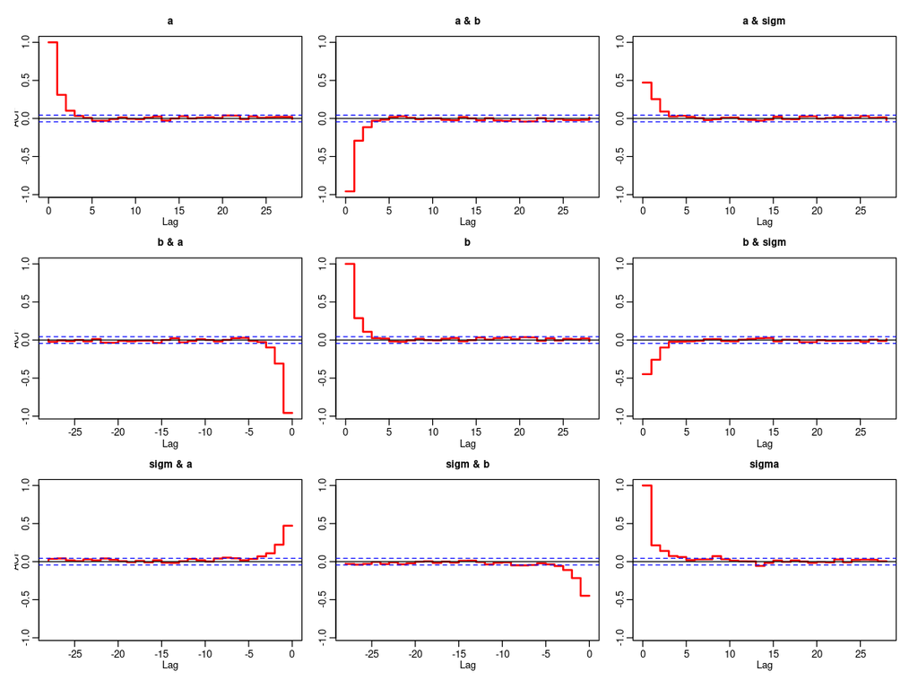

```r
# Your code to generate the plots

# plot the ACF CORRELATIONS
plot(calibration.acf, type = "s", xlab = "Lag", ylab = NULL,
     ylim = NULL, main = NULL, col = "red", lwd = 2)
```

```r
#CORRELATION BETWEEN PARAMS
# Set the figure size
par(mfrow = c(1,3))
for(i in 1:2){
  for(j in (i+1):3){
    points.i <- as.numeric(calibration_mcmc[,i])
points.j <- as.numeric(calibration_mcmc[,j])
plot(points.i, points.j,  col="coral", pch = 1, xlab=cal_names[i], ylab=cal_names[j], cex.lab=1.3, cex.axis=1.3, cex.main=1.3, cex.sub=1.3)
  }
}

dev.off()
```

```r
# mean value of the parameters from the mcmc samples
cal_params <- c(mean(calibration_mcmc[,1]), mean(calibration_mcmc[,2]), mean(calibration_mcmc[,3]))

# vector of values of the channel energy
E_ch_new <- 0:500

#length of the channel energy vector
n <- length(E_ch_new)

# expected value of the linear calibration
fit.pred <- cal_params[1] + E_ch_new * cal_params[2]



#plot the expectation value of the linear fit of the calibration
plot(E_ch_new, fit.pred, main = "Calibration of the NaI detector", type = 'l', xlab = "Channel [ch]", ylab = expression("E"* gamma ~ "[keV]"),lwd = 2, col = "dark red")
```

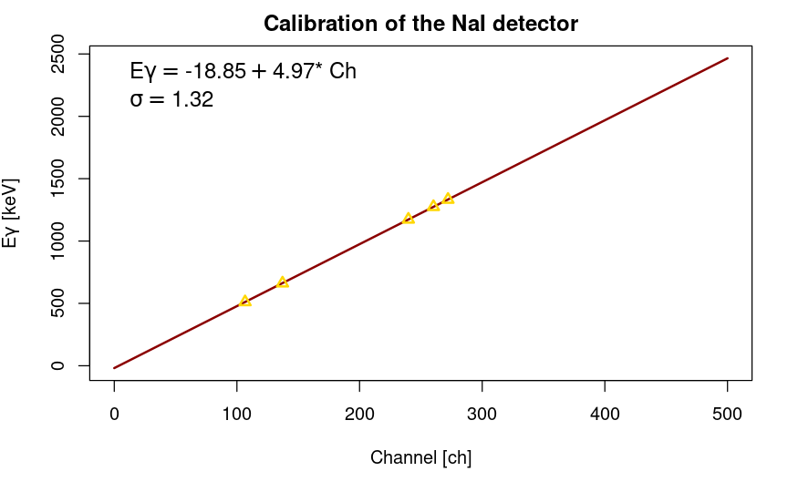

```r
# measurements
points(E_ch, E_gamma, pch = 2, col = "gold", cex = 1, lwd = 2)
# Add legend with formulas
legend_text <- bquote("E"* gamma == .(round(mean(calibration_mcmc[,1]), 2)) + .(round(mean(calibration_mcmc[,2]), 2)) * "* Ch")
sigma_text <- bquote(sigma == .(round(mean(calibration_mcmc[,3]), 2)))
legend("topleft", legend = c(legend_text, sigma_text), bty = "n", cex = 1.2)
```

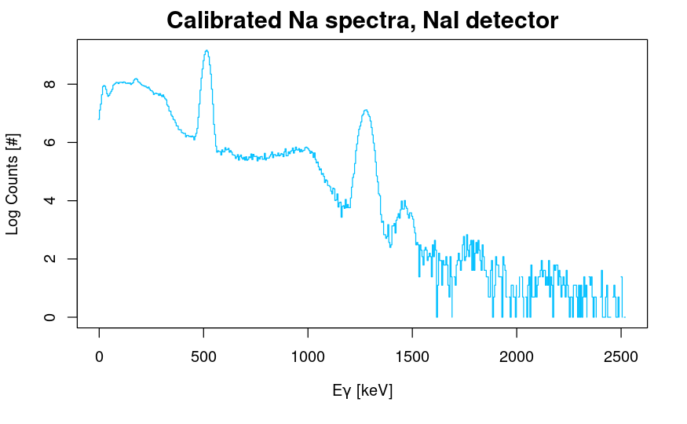

```r
#plot after calibration
Na_dataset$Energy <- Na_dataset$ADC_channel * cal_params[2] + cal_params[1]
Cs_dataset$Energy <- Cs_dataset$ADC_channel * cal_params[2] + cal_params[1]
Co_dataset$Energy <- Co_dataset$ADC_channel * cal_params[2] + cal_params[1]


#plot calibration of Na
plot(Na_dataset$Energy,log(Na_dataset$Counts), type = 's', col='deepskyblue', main = 'Calibrated Na spectra, NaI detector', xlab = expression("E"* gamma ~ "[keV]"), ylab = "Log Counts [#]",cex.main = 1.5)
```

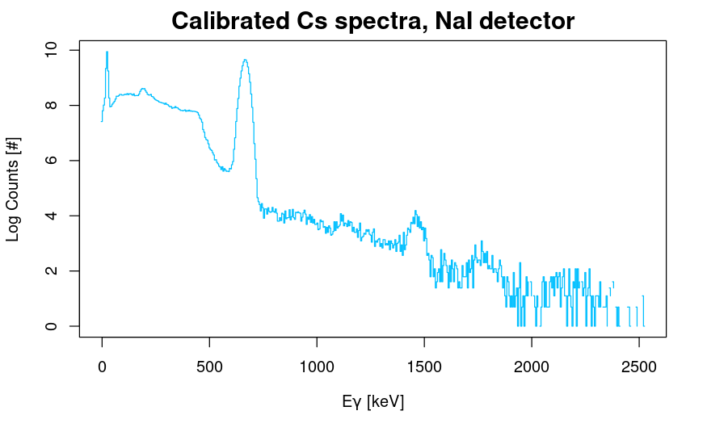

```r
# plot calibration of Cs
plot(Cs_dataset$Energy,log(Cs_dataset$Counts), type = 's', col='deepskyblue', main = 'Calibrated Cs spectra, NaI detector', xlab = expression("E"* gamma ~ "[keV]"), ylab = "Log Counts [#]",cex.main = 1.5)
```

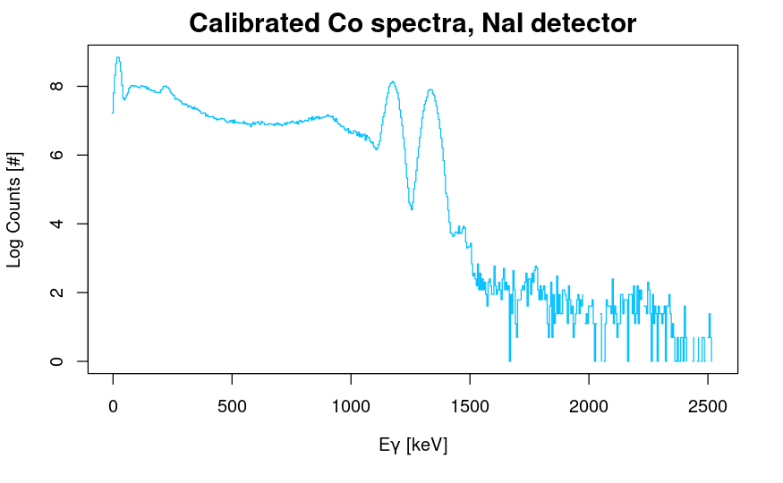

```r
# plot calibration of Cs
plot(Co_dataset$Energy,log(Co_dataset$Counts), type = 's', col='deepskyblue', main = 'Calibrated Co spectra, NaI detector', xlab = expression("E"* gamma ~ "[keV]"), ylab = "Log Counts [#]",cex.main = 1.5)
```

```r
NA
NA
```

## 3. Energy resolution behavior

Using a MCMC method (with either JAGS or stan), study the behaviour of the energy resolution as a function of the photon energy and infer the parameters of eq.1 and 2.

We make an inference using a JAGS model.

Generative model:

$$FWHM = \sqrt{8 ln(2)FwEγ +
w_e^2}$$

note that the Fano factor $F=\dfrac{ \sigma_{sper}^2}{ \sigma_{pois}^2}$. This factor must be introduced since the process giving rise to each individual charge carrier is not independent as the number of ways an atom may be ionized is limited by the discrete electron shells.

Measurement Model:

$$\text{Norm}(\sigma |E, y ) =
\frac{1}{\sqrt{2 \pi}\sigma} \exp \left[ -\frac{(E -
y(x))^2}{2\sigma^2}\right]$$

- $E$: true value of gamma peak, taken from literature
- $y(x)$: values of the peak from the generative model
- $sigma$: standard deviation

```r
#model as .bug file
en.resolution.model <- "model{
    # Likelihood model
    for (i in 1:N){
      FWHM[i] ~ dnorm(y[i], tau) # tau is precision (1 / variance)
          y[i] <- sqrt(8*log(2)*Fw*E[i] + w_e2)
    }
    # Prior model for F,w,w_e
    Fw ~ dunif(0, 1)
    #w ~ dunif(0, 0.5)
    w_e2 ~ dunif(0, 10)

    sigma ~ dunif(0, 1)
    tau <- 1 / (sigma * sigma)

}"

#x <- c(1173.24, 1332.51, 511, 1274.577,661.66) true values of energies
# this is the order of the following vector
# energies of the peak calibrated in keV
x <- c(2.398e+02,  2.721e+02, 1.066526e+02, 2.602560e+02, 1.371767e+02)*cal_params[2] + cal_params[1]
#y <- beta_list
#x
# FWHM in channel
y_ch <- c(4.665*2.35,5.111*2.35,3.144968*2.35,5.115358*2.35, 3.686440*2.35)

# FWHM in energy
# since it is a range of energies the offset is elided
y <- y_ch*cal_params[2]

jm <- jags.model(textConnection(en.resolution.model),
    data = list(E = x, FWHM = y, N = length(y)), n.chain = 3, quiet = TRUE)

#burn-in
update(jm , 1000, progress.bar = "none")

en.resolution <- coda.samples(model = jm, variable.names = c("Fw", "w_e2", "sigma"), n.iter = 10000, thin = 15, progress.bar ="none")

summary(en.resolution)
```

```
Iterations = 2015:11990
Thinning interval = 15
Number of chains = 3
Sample size per chain = 666

1. Empirical mean and standard deviation for each variable,
   plus standard error of the mean:

        Mean       SD  Naive SE Time-series SE
Fw    0.4831 0.007277 0.0001628      0.0001581
sigma 0.8548 0.103700 0.0023200      0.0024393
w_e2  4.9513 2.848267 0.0637211      0.0641958

2. Quantiles for each variable:

        2.5%    25%    50%    75%  97.5%
Fw    0.4687 0.4784 0.4833 0.4881 0.4971
sigma 0.6242 0.7838 0.8747 0.9378 0.9939
w_e2  0.2067 2.4815 4.9433 7.3950 9.7536
```

```r
#pdf("plot_output.pdf")  # Specify the output PDF file name
```

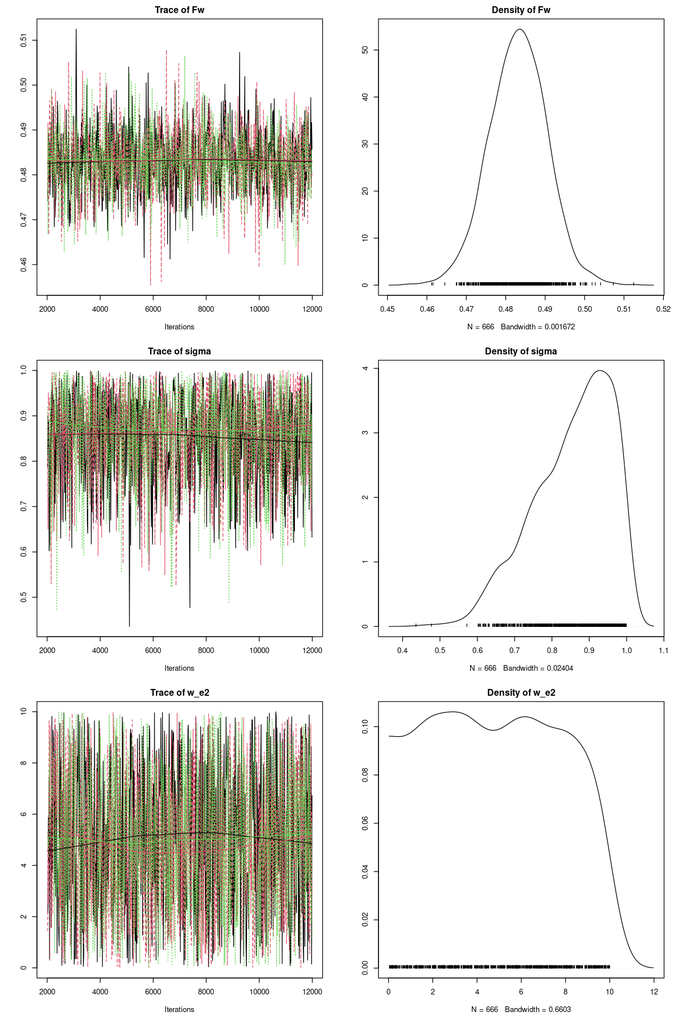

```r
# plot of the coda samples
plot(en.resolution)
```

```r
#dev.off()  # Close the PDF device and save the file


en.resol_mcmc <- as.mcmc(do.call(rbind, en.resolution))
#en.resol_mcmc


#en.resol.acf <- acf(en.resol_mcmc, plot = F) #plot = F will not show the plot of the ACF.

en.resol_names <- c("Fw", expression(sigma), "w_e2")

en.resol_mcmc[,"w_e2"] <- sqrt(en.resol_mcmc[,"w_e2"])

#ACF CORRELATION

#plot(en.resol.acf, type = "s", xlab = "Lag", ylab = NULL,
  #   ylim = NULL, main = NULL, col = "red", lwd = 2)

#CORRELATION BETWEEN PARAMS


par(mfrow = c(1,3))
for(i in 1:2){
  for(j in (i+1):3){
    points.i <- as.numeric(en.resol_mcmc[,i])
points.j <- as.numeric(en.resol_mcmc[,j])
plot(points.i, points.j,  col="coral", pch = 1, xlab=en.resol_names[i], ylab=en.resol_names[j], cex.lab=1.3, cex.axis=1.3, cex.main=1.3, cex.sub=1.3)
  }
}

dev.off()
```

```r
en.res.params <- c(mean(en.resol_mcmc[,1]), mean(en.resol_mcmc[,2]), mean(en.resol_mcmc[,3]))


E <- seq(from = 0, to = 5000, length.out = 10000)
n <- length(E)

en.resol.fit <- sqrt(8*log(2)*en.res.params[1]*E + en.res.params[3]*en.res.params[3])
#plo the data
plot(E, en.resol.fit, main = "NaI detector FWHM vs Energy fit", type = 'l', xlab = expression("E"* gamma ~ "[keV]"), ylab ="FWHM [keV]",lwd = 2, col = "dark red", xlim=c(0,2000))
```

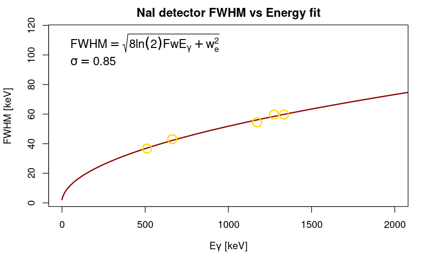

```r
points(x, y, pch = 1, col = "gold", cex = 2, lwd = 2)
# Add legend with formulas
legend("topleft", legend = c(expression(FWHM == sqrt(8*ln(2)*F*w*E[gamma] + w[e]^2)), bquote(sigma == .(round(mean(en.resol_mcmc[,"sigma"]), 2)))), bty = "n", cex = 1.2)
```

```r
summary_fit <- data.frame("F" = mean(en.resol_mcmc[,"Fw"])/0.5, "w[keV]" = 0.5, "w_e[keV]" = mean(en.resol_mcmc[,"w_e2"]))
names(summary_fit) = c("F", "w[keV]", "w_e[keV]")
summary_fit
```

| F | w[keV] | w_e[keV] |
| --- | --- | --- |
| 0.9662884 | 0.5 | 2.099607 |

```r
NA
```

We stress that $w$ is not anymore the electron-hole production energy threshold, since in scintillator detector we have also uncertainty due to PMT. To retrieve the Fano factor $F$ we can just divide $Fw$ by $w$, that now is equal to $w = 0.5 keV$, and is token from: Nilgün Demir, Zehra Nur Kuluöztürk, Determination of energy resolution for a NaI(Tl) detector modeled with FLUKA code, Nuclear Engineering and Technology, https://doi.org/10.1016/j.net.2021.05.017.

Also here we found a Fano Factor smaller than 1.

## 4. FWHM comparison between Ge and NaI detectors

Finally, compare the performances of the two detectors. We collect the results obtained in the data analysis and show the resolution efficiency of the two detectors for the common gamma source 137-Cs and 60-Co.

```r
# FWHM of Ge detector
E_FWHM_Ge <- c(0.8876703, 1.6244367, 2.2690219, 2.4882082)
names(E_FWHM_Ge) <- c("241-Am", "137-Cs", "60-Co 1", "60-Co 2")

# FWHM of NaI detector
E_FWHM_NaI <- c(54.46429, 59.67138, 36.71778, 59.72226, 43.03952)
names(E_FWHM_NaI) <- c("60-Co 1", "60-Co 2", "22-Na 1", "22-Na 2", "137-Cs")

# peaks in common for the Ge and NaI detector
combined_data_det <- data.frame(
  E_FWHM_Ge = E_FWHM_Ge[c( "137-Cs", "60-Co 1", "60-Co 2")],
  E_FWHM_NaI = E_FWHM_NaI[c( "137-Cs", "60-Co 1", "60-Co 2")]
)
```

```r
# plot the FWHM for the peaks in common
barplot(t(combined_data_det), beside = TRUE, col = c("dark red", "springgreen 3"), main = "Comparison of FWHM for Ge and NaI detector", xlab = "Element", ylab = "FWHM [keV]" )
legend("topleft", legend = c("FWHM Ge", "FWHM NaI"), fill = c("dark red", "springgreen 3"))
```

```r
text(x = 1.5, y = 5, labels = "1.62", cex = 1.2)
text(x = 2.5, y = 38, labels = "43.04", cex = 1.2)
```

```r
text(x = 4.5, y = 5, labels = "2.27", cex = 1.2)
text(x = 5.5, y = 49, labels = "54.46", cex = 1.2)
```

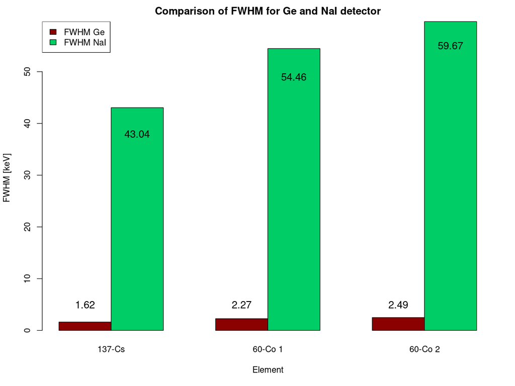

```r
text(x = 7.5, y = 5, labels = "2.49", cex = 1.2)
text(x = 8.5, y = 55, labels = "59.67", cex = 1.2)
```

```r
# summary table of inferred results
Peak <- c("22-Na 1", "22-Na 2", "137-Cs","60-Co 1", "60-Co 2", "241-Am")
Photon_Energy <- c(511, 1274.577, 661.66, 1173.24, 1332.51, 59.54)
Ge_Photon_Energy <- c(NA, NA, 661.75156, 1173.43320, 1332.37122, 59.47234)
NaI_Photon_Detector <- c(511.0411, 1274.1428,  662.6848, 1172.5174, 1332.9838, NA)
Ge_FWHM <- c(NA, NA,1.6244367, 2.2690219, 2.4882082,  0.8876703)
NaI_FWHM <- c(36.71778, 59.72226, 43.03952, 54.46429, 59.67138, NA)

results <- data.frame(list(Peak, Photon_Energy, Ge_Photon_Energy, NaI_Photon_Detector, Ge_FWHM, NaI_FWHM))
colnames(results) <- c("Elements", "Photon Energy [keV]", "Ge Peak [keV]", "NaI Peak [keV]", "Ge FWHM [keV]", "NaI FWHM [keV]")

# ratio between the FWHM of Ge and FWHM of NaI
results$Ratio <-  results$`NaI FWHM [keV]` / results$`Ge FWHM [keV]`
colnames(results) <- c("Elements", "Photon Energy [keV]", "Ge Peak [keV]", "NaI Peak [keV]", "Ge FWHM [keV]", "NaI FWHM [keV]", "Ratio FWHM NaI/Ge")


print(results)
```

| Elements | Photon Energy [keV] | Ge Peak [keV] | NaI Peak [keV] | Ge FWHM [keV] | NaI FWHM [keV] | Ratio FWHM NaI/Ge |
| --- | --- | --- | --- | --- | --- | --- |
| 22-Na 1 | 511.000 | NA | 511.0411 | NA | 36.71778 | NA |
| 22-Na 2 | 1274.577 | NA | 1274.1428 | NA | 59.72226 | NA |
| 137-Cs | 661.660 | 661.75156 | 662.6848 | 1.6244367 | 43.03952 | 26.49504 |
| 60-Co 1 | 1173.240 | 1173.43320 | 1172.5174 | 2.2690219 | 54.46429 | 24.00342 |
| 60-Co 2 | 1332.510 | 1332.37122 | 1332.9838 | 2.4882082 | 59.67138 | 23.98167 |
| 241-Am | 59.540 | 59.47234 | NA | 0.8876703 | NA | NA |

As we can observe from the table, the energy resolution of the Ge detector is approximately 25 times better than the NaI one.